title: covid19_confirmed_cases_in_kerala output: html_document

Load dataset

```r
##loading dataset
data=read.csv("Covid 19 Confirmed Cases-Kerala.csv")
```

head() :shows top few rows in dataset by default it shows the first 6 rows

```r
##to get first few row
head(data)
```

```
##         Date Confirmed
## 1 2020-01-31         0
## 2 2020-02-01         0
## 3 2020-02-02         1
## 4 2020-02-03         1
## 5 2020-02-04         0
## 6 2020-02-05         0
```

shows top 3 rows in the dataset

```r
##to get first 3 row
head(data, n=3)
```

```
##         Date Confirmed
## 1 2020-01-31         0
## 2 2020-02-01         0
## 3 2020-02-02         1
```

to extract data of particular column

```r
head(data$Confirmed)
```

```
## [1] 0 0 1 1 0 0
```

```r
data$Confirmed[3]
```

```
## [1] 1
```

```r
data$Confirmed[1:6]
```

```
## [1] 0 0 1 1 0 0
```

tail() :shows last few rows in dataset by default it shows the last 6 rows

```r
##to get last few row
tail(data)
```

```
##           Date Confirmed
## 552 2021-08-04     22414
## 553 2021-08-05     22040
## 554 2021-08-06     19948
## 555 2021-08-07     20367
## 556 2021-08-08     18607
## 557 2021-08-09     13049
```

displays selected rows and columns

```r
##displays 3rd row and 2nd column
data[3,2]
```

```
## [1] 1
```

as.matrix() converts dataframe into matrix

```r
head(as.matrix(data))
```

```
##      Date         Confirmed
## [1,] "2020-01-31" "    0"
## [2,] "2020-02-01" "    0"
## [3,] "2020-02-02" "    1"
## [4,] "2020-02-03" "    1"
## [5,] "2020-02-04" "    0"
## [6,] "2020-02-05" "    0"
```

rbind() and cbind() create matrices by combining several vectors of same length

```r
##rbind() combines as rows
head(rbind(data))
```

```
##         Date Confirmed
## 1 2020-01-31         0
## 2 2020-02-01         0
## 3 2020-02-02         1
## 4 2020-02-03         1
## 5 2020-02-04         0
## 6 2020-02-05         0
```

```r
##cbind() combines vectors as column
head(cbind(data))
```

```
##         Date Confirmed
## 1 2020-01-31         0
## 2 2020-02-01         0
## 3 2020-02-02         1
## 4 2020-02-03         1
## 5 2020-02-04         0
## 6 2020-02-05         0
```

attach() function used to access the variables present in the data framework without calling the dataframe

```r
data1 = attach(data)
data1
```

```
## <environment: 0x00000000150e6920>
## attr(,"name")
## [1] "data"
```

stack() used to transform data available as separate columns in a dataframe or list into a single column

```r
head(stack(data))
```

```
##       values  ind
## 1 2020-01-31 Date
## 2 2020-02-01 Date
## 3 2020-02-02 Date
## 4 2020-02-03 Date
## 5 2020-02-04 Date
## 6 2020-02-05 Date
```

sort() command sort data in order by default sorts in ascending order

```r
##to sort data
head(sort(data$Confirmed))
```

```
## [1] 0 0 0 0 0 0
```

```r
head(order(data$Confirmed))
```

```
## [1] 1 2 5 6 7 8
```

length() :command used to determine the number of items in an dataset

```r
## to determine number of items
length(data)
```

```
## [1] 2
```

dimnames() gives names of both rows and column

```r
##to see row and column names
dimnames(data)
```

[output not shown]

[output cut: 36 more lines]

class() :command used to see type of data

```r
##class() to obtain info about the type of object
class(dimnames(data))
```

```
## [1] "list"
```

```r
class(data)
```

```
## [1] "data.frame"
```

```r
class(data$Date)
```

```
## [1] "character"
```

```r
class(data$Confirmed)
```

```
## [1] "numeric"
```

str() command shows structure of data

```r
##structure of dataset
str(data)
```

```
## 'data.frame':    557 obs. of  2 variables:
##  $ Date     : chr  "2020-01-31" "2020-02-01" "2020-02-02" "2020-02-03" ...
##  $ Confirmed: num  0 0 1 1 0 0 0 0 0 0 ...
```

structure returns the data with further attributes set

```r
head(structure(data))
```

```
##         Date Confirmed
## 1 2020-01-31         0
## 2 2020-02-01         0
## 3 2020-02-02         1
## 4 2020-02-03         1
## 5 2020-02-04         0
## 6 2020-02-05         0
```

summary() command used to get information about the data

```r
##summary of dataset
summary(data)
```

```
##      Date             Confirmed
##  Length:557         Min.   :    0
##  Class :character   1st Qu.:  111
##  Mode  :character   Median : 3423
##                     Mean   : 6401
##                     3rd Qu.: 7449
##                     Max.   :43529
```

```r
summary(data$Confirmed)
```

```
##    Min. 1st Qu.  Median    Mean 3rd Qu.    Max.
##       0     111    3423    6401    7449   43529
```

```r
##mean of confirmed
mean(data$Confirmed)
```

```
## [1] 6401.37
```

```r
##median of confirmed
median(data$Confirmed)
```

```
## [1] 3423
```

```r
##maximum number in confirmed column
max(data$Confirmed)
```

```
## [1] 43529
```

```r
##mode of confirmed data
mode(data$Confirmed)
```

```
## [1] "numeric"
```

```r
##minimum value in confirmed data
min(data$Confirmed)
```

```
## [1] 0
```

```r
##standard deviation of confirmed data
sd(data$Confirmed)
```

```
## [1] 8686.932
```

```r
##variance in confirmed data
var(data$Confirmed)
```

```
## [1] 75462789
```

```r
##median absolute deviation of confirmed data
mad(data$Confirmed)
```

```
## [1] 4975.606
```

quantile of confirmed data with 25th, 50th, 75th percentile

```r
##quantile 25%,50%,75%
quantile(data$Confirmed, 0.25)
```

```
## 25%
## 111
```

```r
quantile(data$Confirmed, 0.5)
```

```
##  50%
## 3423
```

```r
quantile(data$Confirmed, 0.75)
```

```
##  75%
## 7449
```

```r
quantile(data$Confirmed, c(0.25,0.5,0.75))
```

```
##  25%  50%  75%
##  111 3423 7449
```

returns five number summary of confirmed data(min, lower-hinge,median,upper-hinge, max)

```r
#five number of data
fivenum(data$Confirmed)
```

```
## [1]     0   111  3423  7449 43529
```

ls.str() displays the internal structure of R object

```r
## all the named objects at once using ls.str() command
ls.str(data)
```

```
## Confirmed :  num [1:557] 0 0 1 1 0 0 0 0 0 0 ...
## Date :  chr [1:557] "2020-01-31" "2020-02-01" "2020-02-02" "2020-02-03" ...
```

```r
ls.str(pattern = "data")
```

```
## data : 'data.frame': 557 obs. of  2 variables:
##  $ Date     : chr  "2020-01-31" "2020-02-01" "2020-02-02" "2020-02-03" ...
##  $ Confirmed: num  0 0 1 1 0 0 0 0 0 0 ...
## data1 : <environment: 0x00000000150e6920>
```

```r
##rank of data
rank(data$date)
```

```
## numeric(0)
```

```r
rank(data$confirmed)
```

```
## numeric(0)
```

displays first column

```r
##to display first column
head(data[1])
```

```
##         Date
## 1 2020-01-31
## 2 2020-02-01
## 3 2020-02-02
## 4 2020-02-03
## 5 2020-02-04
## 6 2020-02-05
```

cummulative commands

```r
##cummulative sum
head(cumsum(data$Confirmed))
```

```
## [1] 0 0 1 2 2 2
```

```r
##cumulative max
head(cummax(data$Confirmed))
```

```
## [1] 0 0 1 1 1 1
```

```r
##cummulative min
head(cummin(data$Confirmed))
```

```
## [1] 0 0 0 0 0 0
```

```r
##cummulative product
head(cumprod(data$Confirmed))
```

```
## [1] 0 0 0 0 0 0
```

install.packages() to install packages from repositories

```r
install.packages("dplyr", repos = "https://cran.us.r-project.org")
install.packages("magrittr",repos = "https://cran.us.r-project.org")
```

```r
install.packages("ggplot2", repos = "https://cran.us.r-project.org")
```

installed.packages() to see packages which are installed

```r
##to see installed packages
head(installed.packages())
```

[output not shown]

search() command to see all the packages available

```r
##to see all the packages
search()
```

```
##  [1] ".GlobalEnv"        "data"              "package:stats"
##  [4] "package:graphics"  "package:grDevices" "package:utils"
##  [7] "package:datasets"  "package:methods"   "Autoloads"
## [10] "package:base"
```

library() command to load the packages

```r
##to Load the packages
library(dplyr)
```

```r
library(magrittr)
library(ggplot2)
```

mutate() to add new column for existing dataset

```r
##to add new column to dataset with values NA
head(data %>% mutate(necol = NA))
```

```
##         Date Confirmed necol
## 1 2020-01-31         0    NA
## 2 2020-02-01         0    NA
## 3 2020-02-02         1    NA
## 4 2020-02-03         1    NA
## 5 2020-02-04         0    NA
## 6 2020-02-05         0    NA
```

select(-x) command selects the columns based on condition

```r
##select() command to select columns removing confirmed column
head(select(data, -Confirmed))
```

```
##         Date
## 1 2020-01-31
## 2 2020-02-01
## 3 2020-02-02
## 4 2020-02-03
## 5 2020-02-04
## 6 2020-02-05
```

```r
head(data %>% select(-Confirmed))
```

```
##         Date
## 1 2020-01-31
## 2 2020-02-01
## 3 2020-02-02
## 4 2020-02-03
## 5 2020-02-04
## 6 2020-02-05
```

names() command to view name of column and row

```r
##row names and column named
rownames(data)
```

[output not shown]

[output cut: 32 more lines]

```r
colnames(data)
```

```
## [1] "Date"      "Confirmed"
```

```r
names(data)
```

```
## [1] "Date"      "Confirmed"
```

rename() command to change the name of the column

```r
##to make a copy of dataset and rename column name
temp = data
head(temp %>% rename(Confirm = Confirmed))
```

```
##         Date Confirm
## 1 2020-01-31       0
## 2 2020-02-01       0
## 3 2020-02-02       1
## 4 2020-02-03       1
## 5 2020-02-04       0
## 6 2020-02-05       0
```

to change the column position

```r
##to bring last column to first
head(data %>% select(Confirmed,Date))
```

```
##   Confirmed       Date
## 1         0 2020-01-31
## 2         0 2020-02-01
## 3         1 2020-02-02
## 4         1 2020-02-03
## 5         0 2020-02-04
## 6         0 2020-02-05
```

```r
head(data %>% select(Confirmed,everything()))
```

```
##   Confirmed       Date
## 1         0 2020-01-31
## 2         0 2020-02-01
## 3         1 2020-02-02
## 4         1 2020-02-03
## 5         0 2020-02-04
## 6         0 2020-02-05
```

table() command gives number of time the values repeated

```r
##to see how many no of times the value repeated
table(data$Confirmed)
```

```
##
##     0     1     2     3     4     5     6     7     8     9    10    11    12
##    45     6     7     5     2     1     3     6     4     3     4     4     4
##    13    14    15    16    19    20    21    24    26    28    29    32    39
##     2     2     1     1     2     1     1     3     1     1     1     1     1
##    40    42    49    53    54    57    58    61    62    65    67    75    78
##     1     1     1     1     1     1     1     1     2     1     1     1     1
##    79    82    83    85    86    91    94    97   107   108   111   118   122
##     1     2     1     2     1     2     1     1     1     1     1     2     1
##   123   127   131   133   138   141   150   151   152   160   193   195   211
##     1     1     1     1     1     1     1     1     1     1     1     1     1
##   225   240   272   301   339   416   435   449   488   506   593   608   623
##     1     1     1     1     1     1     1     1     1     1     1     1     1
##   702   720   722   791   794   821   885   903   927   962  1038  1054  1078
##     1     1     1     1     1     1     1     1     1     1     1     1     1
```

[output cut: 58 more lines]

```r
head(as.table(data$Confirmed))
```

```
## A B C D E F
## 0 0 1 1 0 0
```

to check the data is in dataframe or not

```r
is.data.frame(data)
```

```
## [1] TRUE
```

```r
is.table(data)
```

```
## [1] FALSE
```

seq_along() function creates vector that contains a sequence of numbers from 1 to the length of the object

```r
seq_along(data)
```

```
## [1] 1 2
```

stem() command extracts the numeric data and splits them into two parts namely, the stem and leaf

```r
stem(data$Confirmed)
```

```
##
##   The decimal point is 3 digit(s) to the right of the |
##
##    0 | 00000000000000000000000000000000000000000000000000000000000000000000+138
##    2 | 00000001111122223344444555555556777788888999900001112333344445555677
##    4 | 00111123445555666666777899990000001112222333344444444455555556666777
##    6 | 00000001122222333333333444455668888900000002344455678889
##    8 | 00111345568888033339
##   10 | 069456668
##   12 | 1111223455688903666788888
##   14 | 00124457666
##   16 | 122835558
##   18 | 356967899
##   20 | 467849
##   22 | 011134457
##   24 | 28
##   26 | 0705
##   28 | 4558778
##   30 | 53
##   32 | 0788
##   34 | 7068
##   36 | 223
##   38 | 56
##   40 | 0
##   42 | 0055
```

```r
##increasing the number of bins by adding a scale = 2 instruction
stem(data$Confirmed, scale = 2)
```

```
##
##   The decimal point is 3 digit(s) to the right of the |
##
##    0 | 00000000000000000000000000000000000000000000000000000000000000000000+98
##    1 | 0011111122222222333444555566666788889999
##    2 | 000000011111222233444445555555567777888889999
##    3 | 000011123333444455556777888
##    4 | 0011112344555566666677789999
##    5 | 0000001112222333344444444455555556666777777888889999
##    6 | 000000011222223333333334444556688889
##    7 | 00000002344455678889
##    8 | 00111345568888
##    9 | 033339
##   10 | 069
##   11 | 456668
```

[output cut: 32 more lines]

filter() gives rows where conditions are true

```r
##filter() command to get data when confirmed is 0
filter(data,Confirmed == 0)
```

```
##          Date Confirmed
## 1  2020-01-31         0
## 2  2020-02-01         0
## 3  2020-02-04         0
## 4  2020-02-05         0
## 5  2020-02-06         0
## 6  2020-02-07         0
## 7  2020-02-08         0
## 8  2020-02-09         0
## 9  2020-02-10         0
## 10 2020-02-11         0
## 11 2020-02-12         0
## 12 2020-02-13         0
## 13 2020-02-14         0
## 14 2020-02-15         0
```

[output cut: 31 more lines]

to calculate new column based on existing column

```r
##add new column named "meanconfirmed" which is calculated based on existing "confirmed" column
head(data %>% mutate(meanconfirmed = Confirmed-mean(Confirmed )))
```

```
##         Date Confirmed meanconfirmed
## 1 2020-01-31         0      -6401.37
## 2 2020-02-01         0      -6401.37
## 3 2020-02-02         1      -6400.37
## 4 2020-02-03         1      -6400.37
## 5 2020-02-04         0      -6401.37
## 6 2020-02-05         0      -6401.37
```

to plot dotplot with ggplot

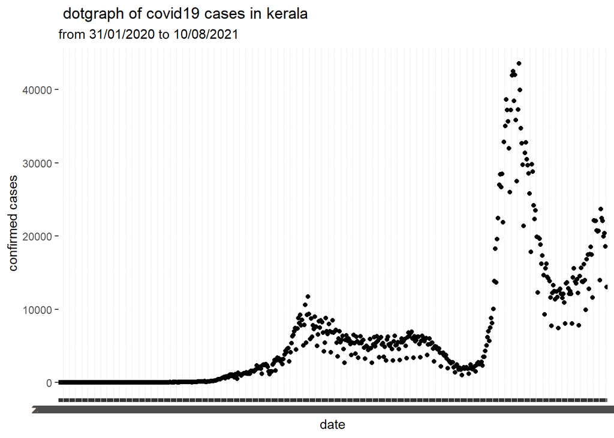

```r
##the covid cases confirmed on particular dates  is plotted with pointgraph (date vs confirmed)
ggplot(data = data, aes(x = Date, y = Confirmed))+geom_point()+labs(x = "date", y = "confirmed cases", title = " dotgraph of covid19 cases in kerala", subtitle = "from 31/01/2020 to 10/08/2021")
```

to plot bargraph with ggplot

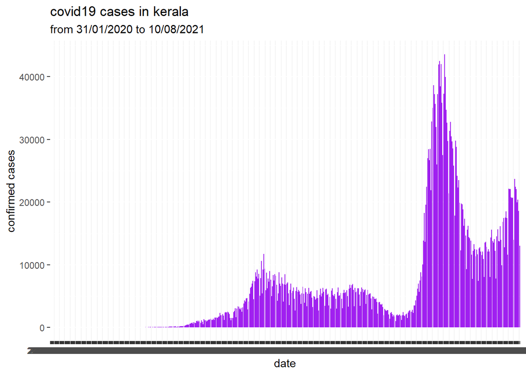

```r
##to plot bargraph of covid cases confirmed on particular dates
ggplot(data = data, aes(x = Date, y = Confirmed))+geom_bar(stat = "identity", fill = "purple")+labs(x = "date", y = "confirmed cases", title = "covid19 cases in kerala", subtitle = "from 31/01/2020 to 10/08/2021")
```

plot() function to create a graphical representation of some data

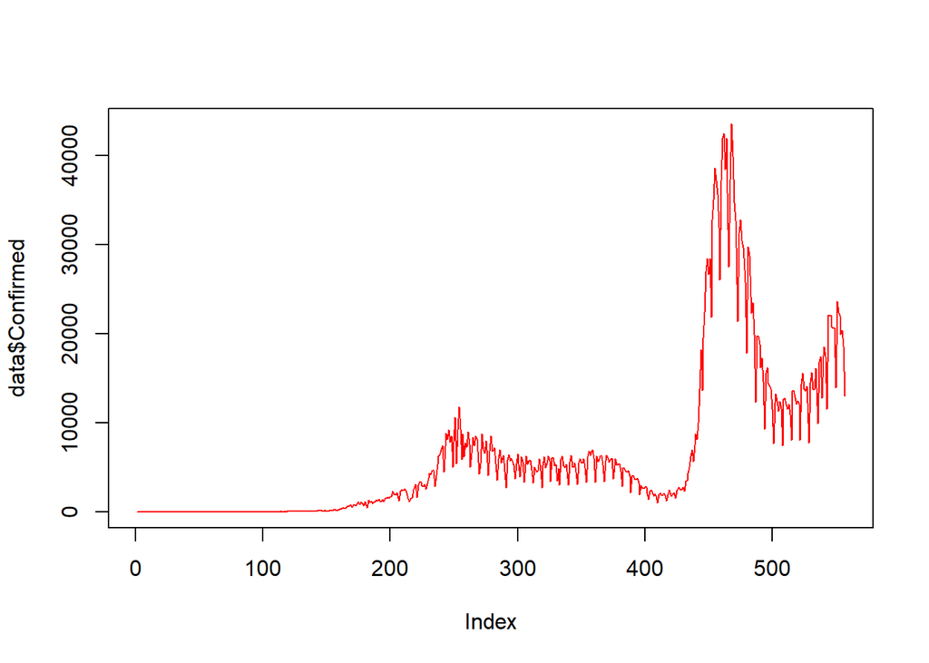

```r
##plots line
plot(data$Confirmed, type = 'l', col = 'red')
```

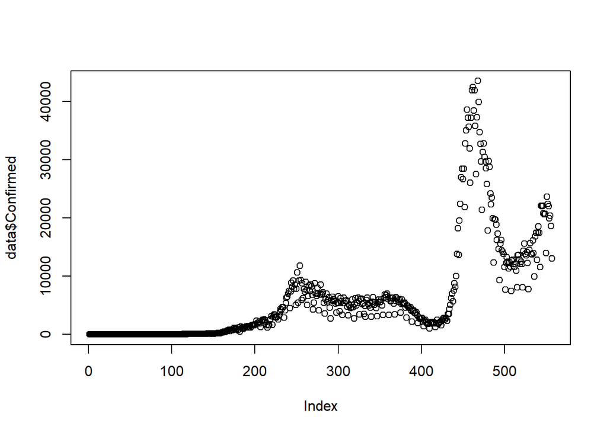

```r
##plots point
plot(data$Confirmed, type = "p")
```

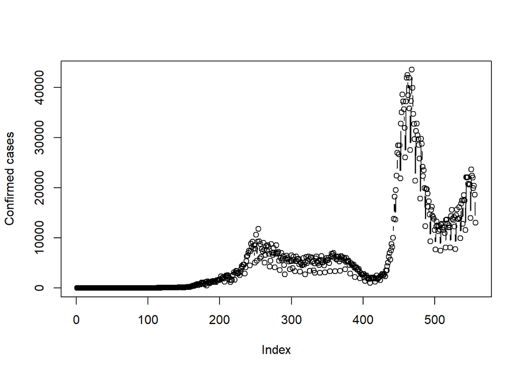

```r
##plots both line and point
plot(data$Confirmed, type = 'b', axes = TRUE, ylab = 'Confirmed cases')
```

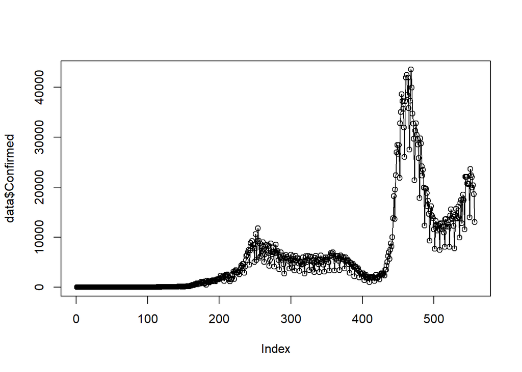

```r
##to plot overplotted points and lines
plot(data$Confirmed, type = "o")
```

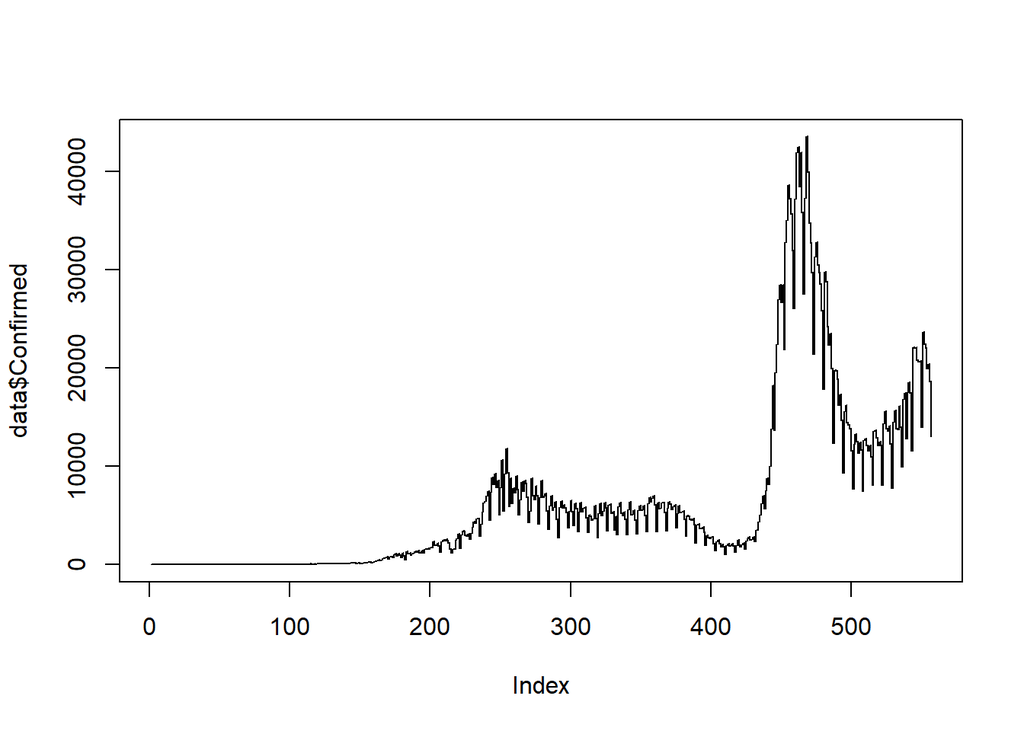

```r
##to plot stair steps
plot(data$Confirmed, type = "s")
```

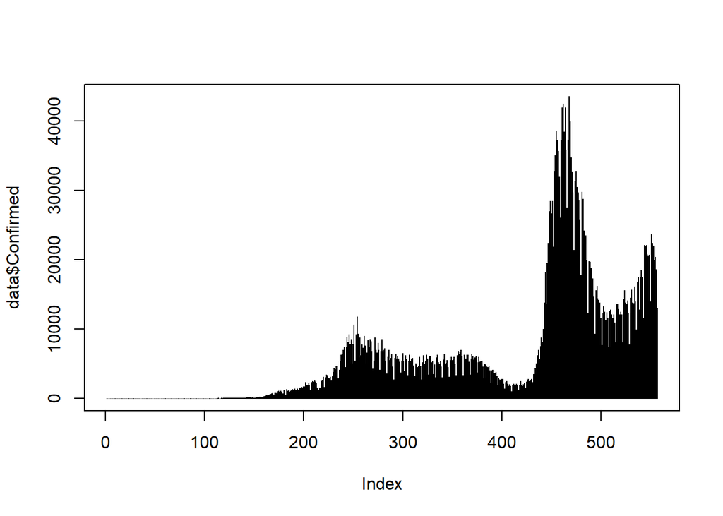

```r
##to plot histogram
plot(data$Confirmed, type = "h")
```

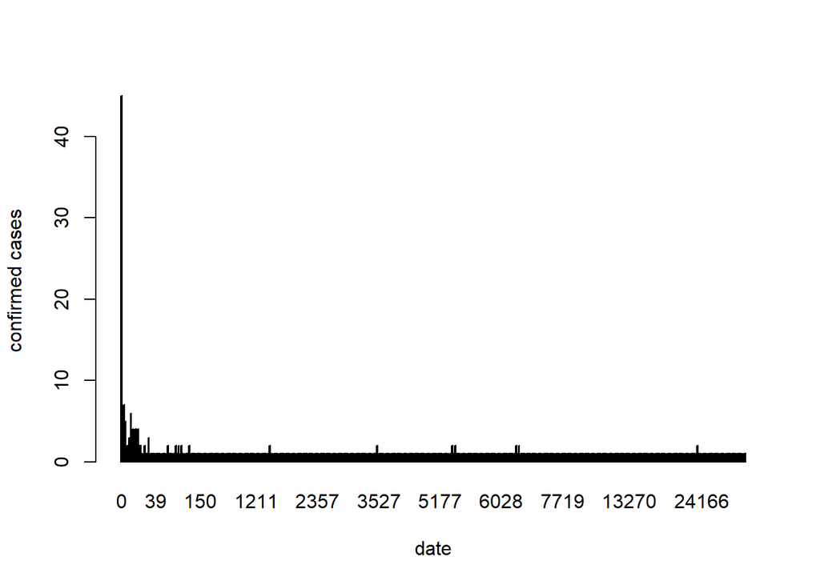

```r
##bar plot
barplot(table(data$Confirmed), xlab = 'date', ylab = 'confirmed cases')
```

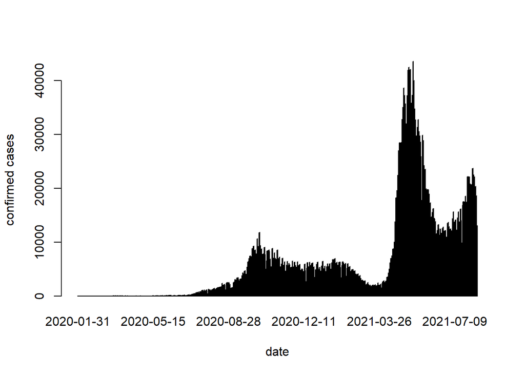

```r
barplot(data$Confirmed, names = data$Date, xlab = 'date', ylab = 'confirmed cases')
```

installing lubridate package that makes it easier to work with dates. load that package

```r
## install lubridate package
install.packages("lubridate", repos = "https://cran.us.r-project.org")
library(lubridate)
```

using mutate() add new columns “year” and “month” by separating year and month form date(year-month-date) using group_by() group the data by months and year using summarise() create new dataframe with fewer rows

```r
##to separate date as month and year
new_data= data %>% mutate(year = year(Date), month = month(Date)) %>% group_by(year, month) %>%  summarise(mean_var = mean(Confirmed))
```

filter() filters the data and gives the data of confirmed cases from date “25-7-2021” to “1-8-2021”

```r
##filter date and get data between 1aug2021 and 10aug2021
fildata = data %>% filter(Date >= as.Date("2021-07-25") & Date <= as.Date("2021-08-01"))
```

pie() to plot piechart of confirmed cases for filtered data(i.e from “25-7-2021” to “1-8-2021” )

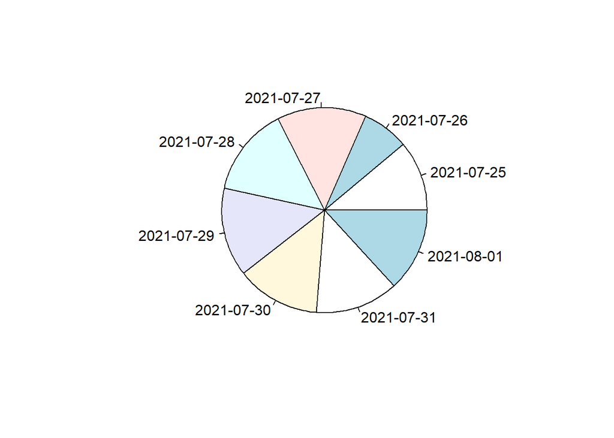

```r
##pie graph
pie(fildata$Confirmed, labels = fildata$Date)
```

as.Date() function used to change the format of date

```r
##create new data>frame with the newly formatted date field
head(data %>% mutate(Date = as.Date(Date , format = "%Y-%m-%d")))
```

```
##         Date Confirmed
## 1 2020-01-31         0
## 2 2020-02-01         0
## 3 2020-02-02         1
## 4 2020-02-03         1
## 5 2020-02-04         0
## 6 2020-02-05         0
```

hist() computes histogram of the given datavalues geom_histogram() plots histogram using ggplot.

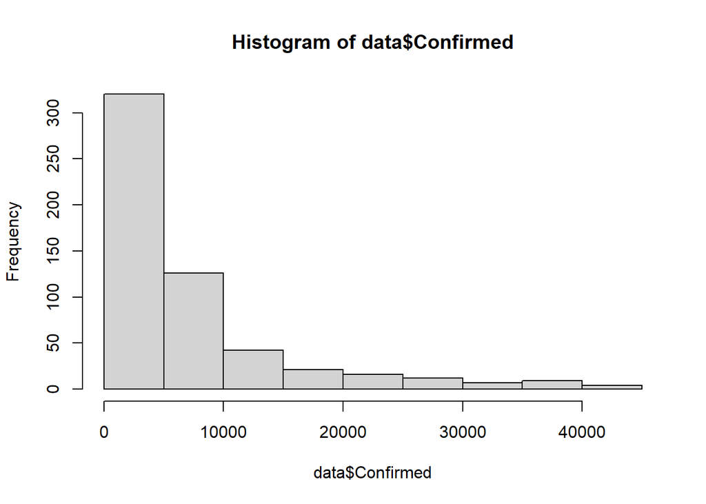

```r
##plot histogram
hist(data$Confirmed)
```

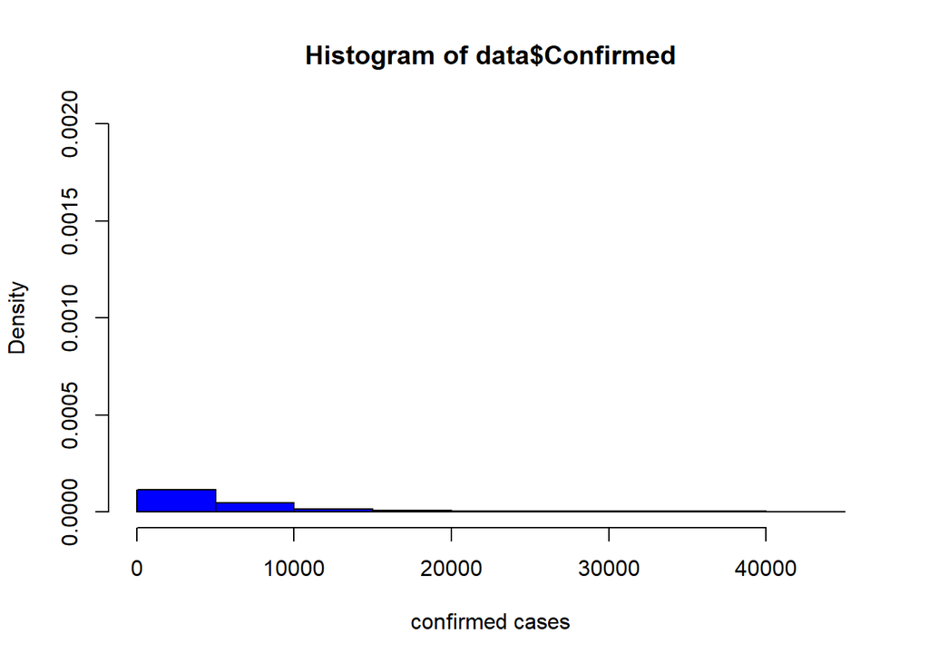

```r
##histogram is plotted with the function hist() and the option freq = False plots probability densities instead of frequencies
hist(data$Confirmed, col = "blue", xlab = "confirmed cases", ylim = c(0, 0.002), freq = FALSE)
```

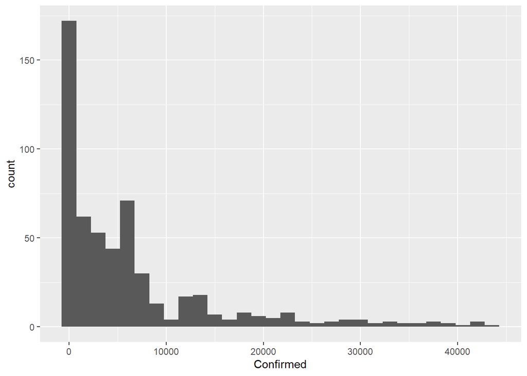

```r
##using ggplot histogram can be plotted using geom_histogram() function
ggplot(data, aes(x = Confirmed)) + geom_histogram()
```

calculating density using density() function

```r
density(data$Confirmed)
```

```
##
## Call:
##  density.default(x = data$Confirmed)
##
## Data: data$Confirmed (557 obs.); Bandwidth 'bw' = 1392
##
##        x               y
##  Min.   :-4175   Min.   :6.450e-09
##  1st Qu.: 8795   1st Qu.:2.971e-06
##  Median :21765   Median :6.209e-06
##  Mean   :21765   Mean   :1.925e-05
##  3rd Qu.:34734   3rd Qu.:1.653e-05
##  Max.   :47704   Max.   :1.146e-04
```

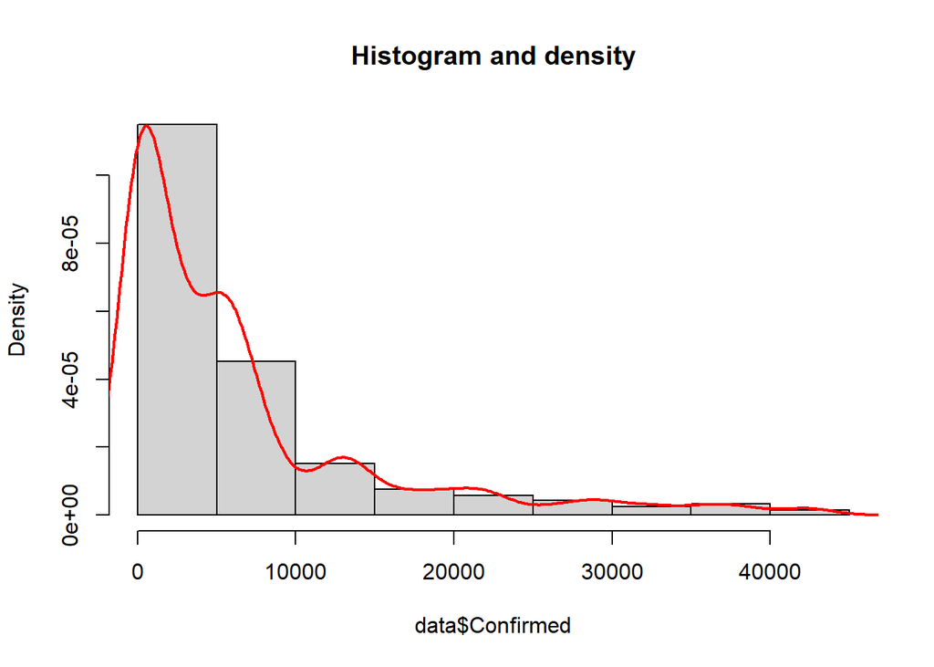

```r
##to plot histogram
hist(data$Confirmed, freq = FALSE, main = "Histogram and density")
##add density to plot
lines(density(data$Confirmed), lwd = 2, col ="red")
```

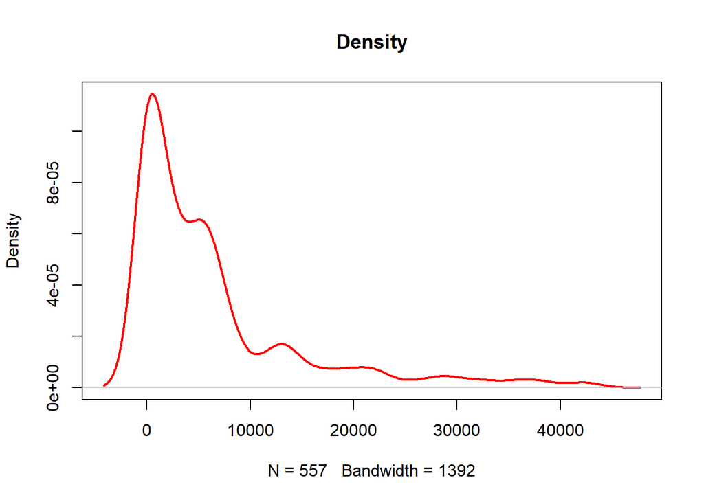

```r
##plots the density without histogram
plot(density(Confirmed), lwd = 2, col = "red", main = "Density")
```

rnorm() function simulates random variates having a specified normal distribution

```r
##with mean =0 and standarddeviation = 1
head(rnorm(data$Confirmed, mean = 0 ,sd = 1))
```

```
## [1] -0.4331661  1.7421246  1.1694141  0.4009756 -0.6630838 -0.1507514
```

pnorm() function gives the cumulative disttribution function(CDF) of the normal distribution

```r
head(pnorm(data$Confirmed, mean = 0 , sd = 1))
```

```
## [1] 0.5000000 0.5000000 0.8413447 0.8413447 0.5000000 0.5000000
```

qnorm() function calculates the inverse of CDF of the normal distribution

```r
head(qnorm(data$Confirmed, mean = 0 , sd = 1))
```

```
## [1] -Inf -Inf  Inf  Inf -Inf -Inf
```

dnorm() function calculates the probability density function of the normal distribution

```r
head(dnorm(data$Confirmed, mean = 0 , sd = 1))
```

```
## [1] 0.3989423 0.3989423 0.2419707 0.2419707 0.3989423 0.3989423
```

normal Q-Q plot qqnorm() is a generic function which produces a normal qq plot

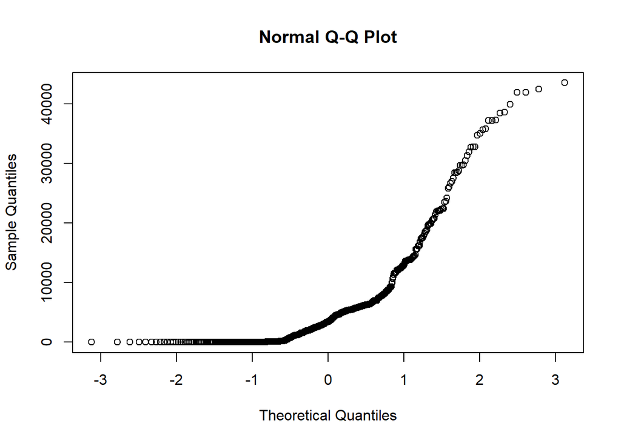

```r
qqnorm(Confirmed)
```

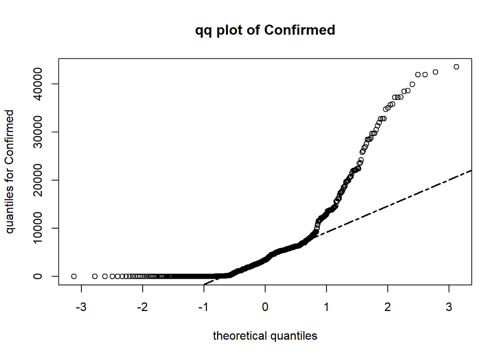

```r
qqnorm(Confirmed, main = "qq plot of Confirmed", xlab = "theoretical quantiles", ylab = "quantiles for Confirmed")
qqline(data$Confirmed, lwd = 2, lty = 6)
```

t.test() function performs t-tests. t-test used to determine whether the means of two groups are equal to eachother

```r
##mean specified by the null hypothesis mu = 0
t.test(Confirmed, mu =5)
```

```
##
##  One Sample t-test
##
## data:  Confirmed
## t = 17.378, df = 556, p-value < 2.2e-16
## alternative hypothesis: true mean is not equal to 5
## 95 percent confidence interval:
##  5678.378 7124.362
## sample estimates:
## mean of x
##   6401.37
```

```r
t.test(Confirmed, mu =5, alternative = "greater")
```

```
##
##  One Sample t-test
##
## data:  Confirmed
## t = 17.378, df = 556, p-value < 2.2e-16
## alternative hypothesis: true mean is greater than 5
## 95 percent confidence interval:
##  5794.926      Inf
## sample estimates:
## mean of x
##   6401.37
```

chisq.test() function used to perform chi-square test

```r
chisq.test(Confirmed)
```

```
##
##  Chi-squared test for given probabilities
##
## data:  Confirmed
## X-squared = 6554427, df = 556, p-value < 2.2e-16
```

there are two types of barcharts geom_bar() and geom_col() . geom_bar() makes the height of the bar proportional to the number of cases in each group, geom_col() to represent values in the data

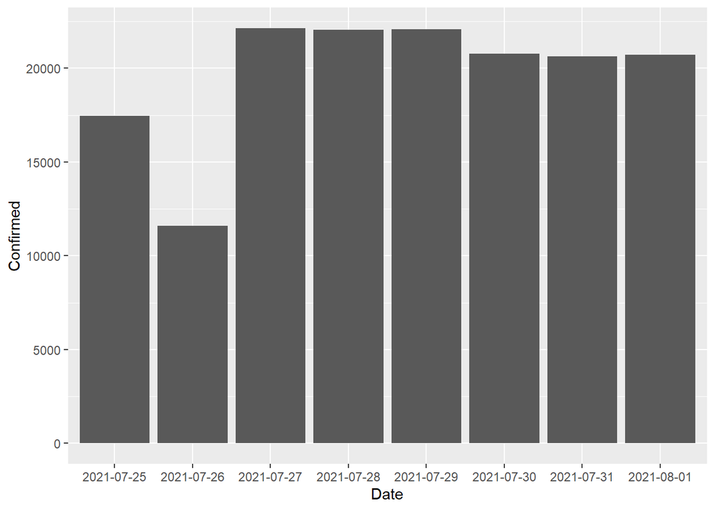

```r
##basic bar graph
library(gcookbook)
ggplot(fildata, aes(x = Date, y = Confirmed))+geom_col()
```

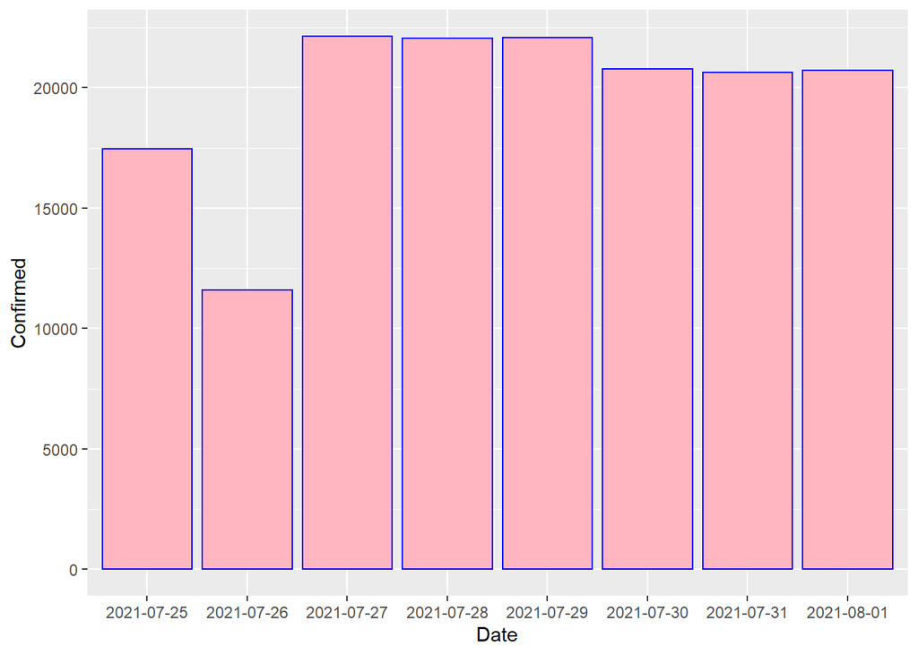

```r
ggplot(fildata, aes(x = Date, y = Confirmed))+geom_col(fill = "lightpink", colour = "blue")
```

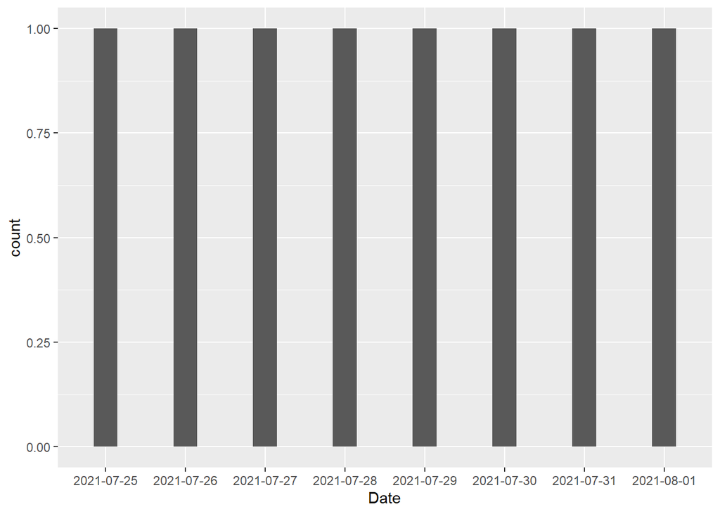

```r
ggplot(fildata, aes(x = Date)) + geom_bar(width = 0.3, position = position_dodge(0.5))
```

filter data by date from 2020-03-09 to 2020-03-20 and the plot bargraph using geom_col in ggplot

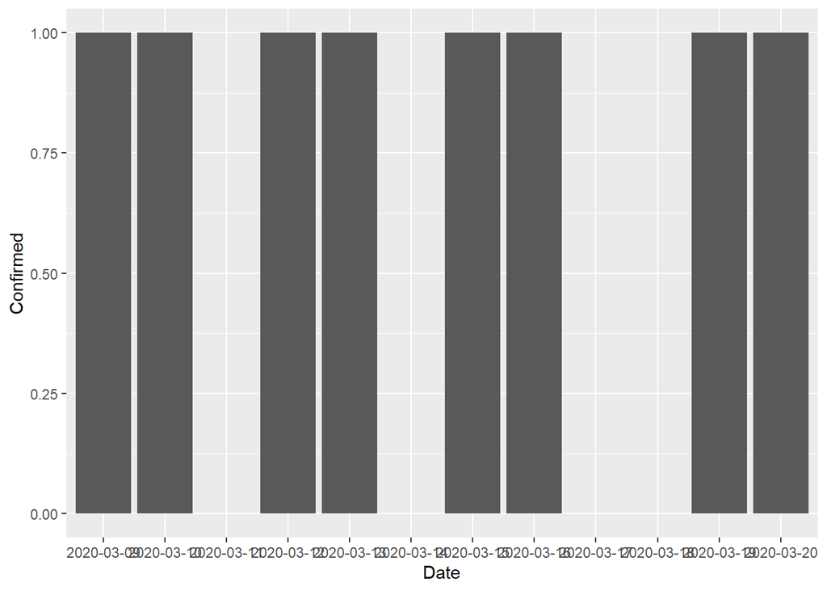

```r
newdata = data %>% filter(Date >= as.Date("2020-03-09") & Date <= as.Date("2020-03-20"))
ggplot(newdata, aes(x= Date, y=Confirmed)) + geom_col(position = 'fill') + scale_fill_brewer(palette = "Pastel1")
```

group the data by date and add new column named “percent_confirmed” which is percentage og comfirmed data and plot bargraph date vs percent_confirmed

```r
## grouping data by Date and calculating percentage of confirmed cases and add that to existing dataset as percent_confirmed using mutate
head(data %>% group_by(Date))
```

```
## # A tibble: 6 x 2
## # Groups:   Date [6]
##   Date       Confirmed
##   <chr>          <dbl>
## 1 2020-01-31         0
## 2 2020-02-01         0
## 3 2020-02-02         1
## 4 2020-02-03         1
## 5 2020-02-04         0
## 6 2020-02-05         0
```

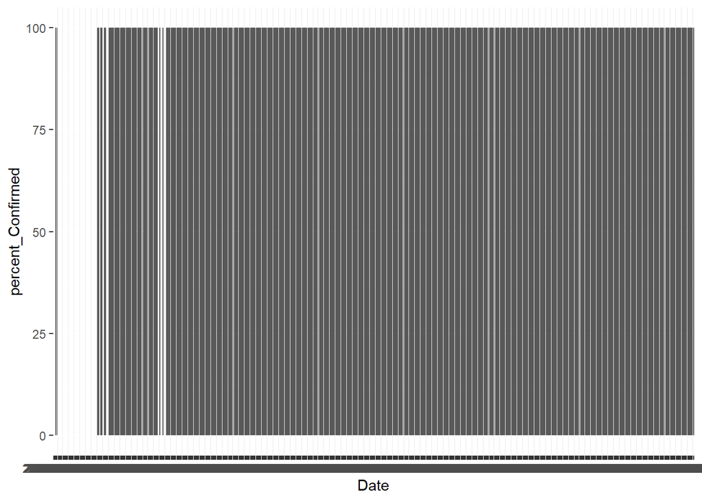

```r
new_data = data %>% group_by(Date) %>% mutate( percent_Confirmed = Confirmed / sum(Confirmed) * 100)
ggplot(new_data , aes(x = Date, y = percent_Confirmed))+ geom_col()
```

new columns “year” and “month” is added ang grouping that data by moth and year

```r
##seperate date into month and year
data = data %>% mutate(year = year(Date), month = month(Date)) %>% group_by(year, month)
##stem with conditional statement
with(data, stem(data$Confirmed[data$year == "2020"]))
```

```
##
##   The decimal point is 3 digit(s) to the right of the |
##
##    0 | 00000000000000000000000000000000000000000000000000000000000000000000+98
##    1 | 001111122222223334455566666789
##    2 | 00223444555577799
##    3 | 000112334445688
##    4 | 0112345566677899
##    5 | 000022234444444455567778888999
##    6 | 00022233333445566889
##    7 | 00000234456889
##    8 | 0134556888
##    9 | 0333
##   10 | 6
##   11 | 8
```

plotting bargraph month vs confirmed and adding labels

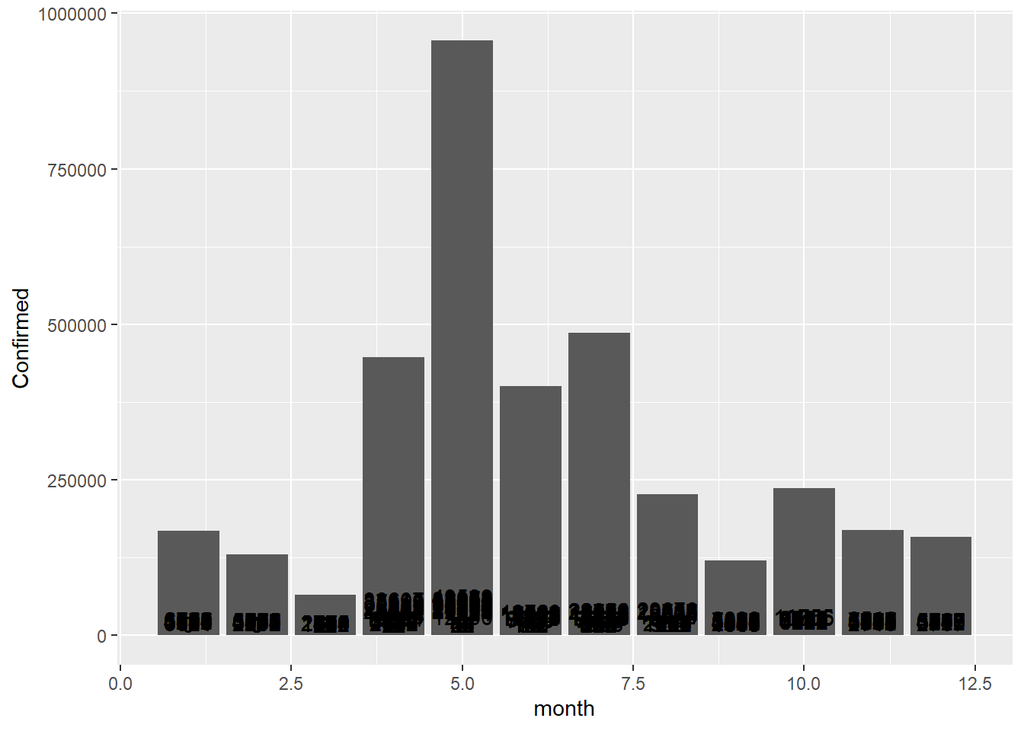

```r
##adding labels to a bar graph
ggplot(data, aes(x= month, y=Confirmed)) + geom_col() + geom_text(aes(label = Confirmed), vjust = -0.2)
```

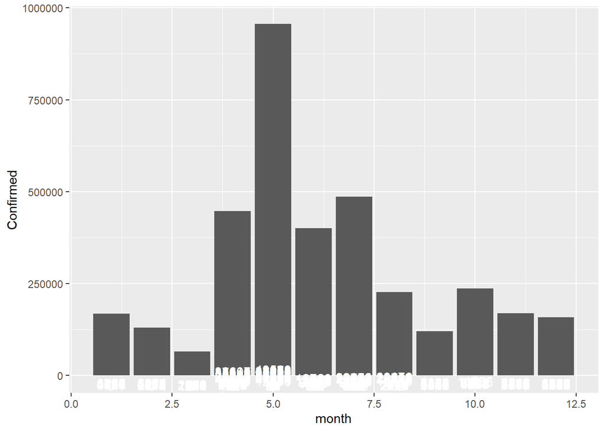

```r
ggplot(data, aes(x= month, y=Confirmed)) + geom_col() + geom_text(aes(label = Confirmed), vjust = 1.5, colour = "white")
```

to plot boxplots

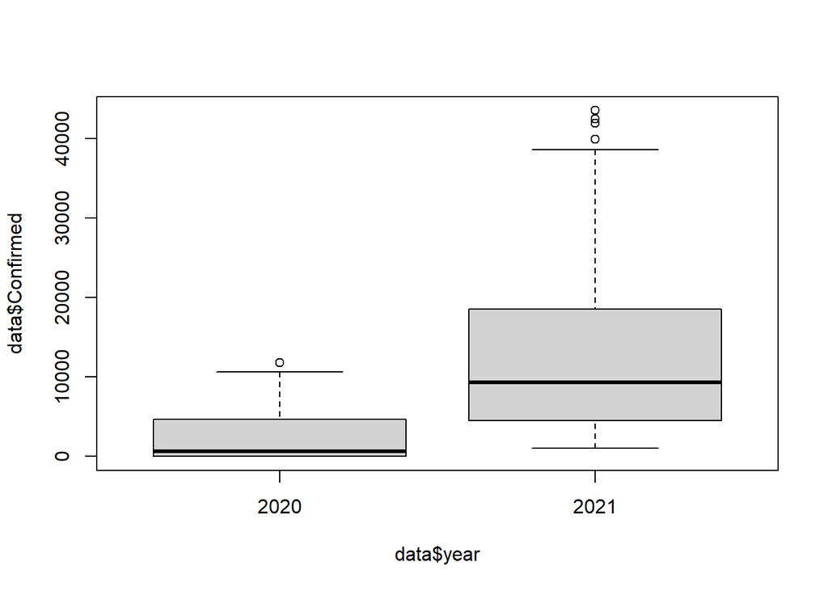

```r
## to plot boxplot
boxplot(data$Confirmed ~ data$year, data = data)
```

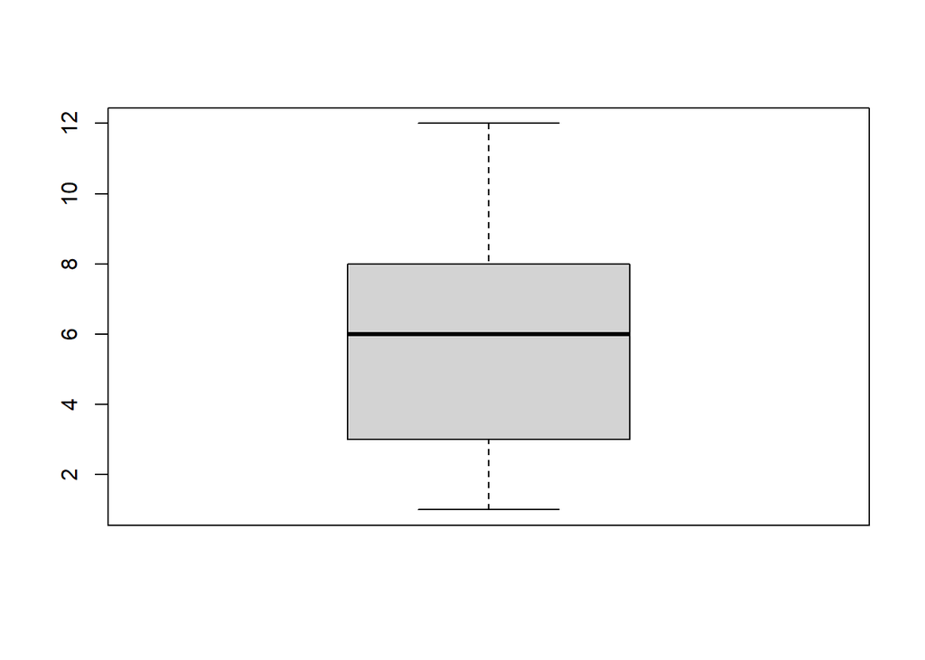

```r
boxplot(data$month)
```

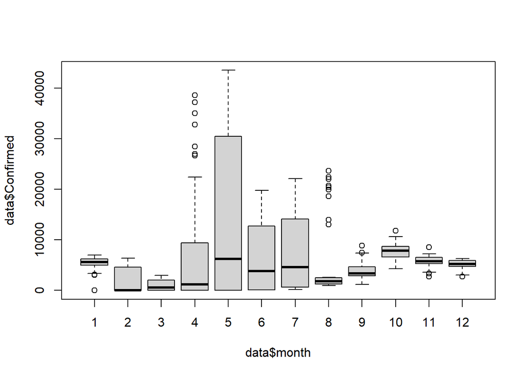

```r
boxplot(data$Confirmed ~ data$month)
```

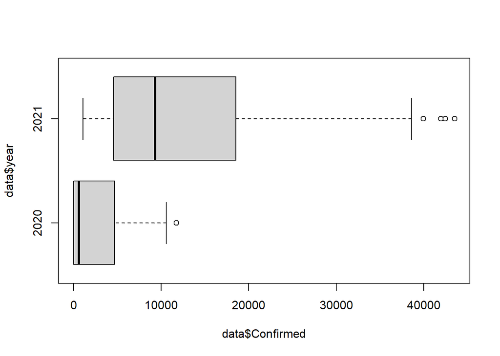

```r
boxplot(data$Confirmed ~ data$year, horizontal = T)
```

plotting line graph in ggplot using geom_line()

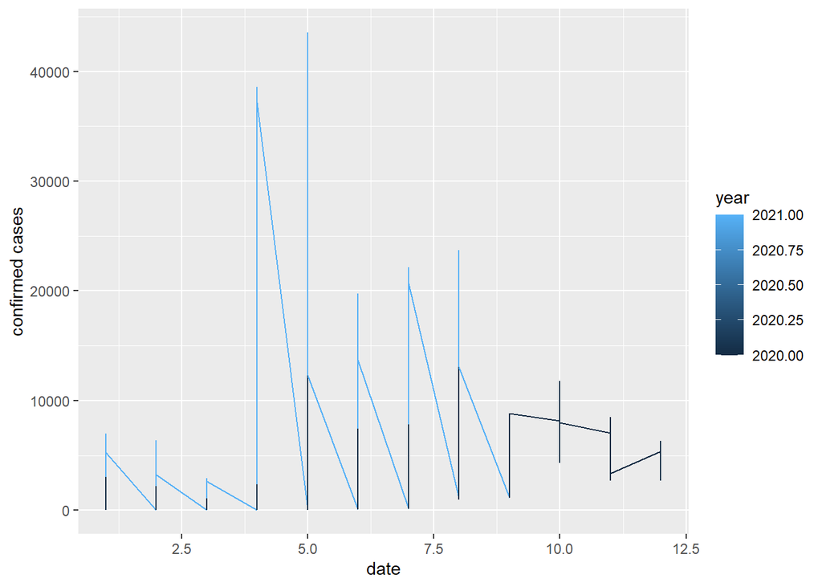

```r
##to plot linegraph
ggplot(data, aes(x = month, y = Confirmed))+geom_line(aes(color = year))+labs(x = "date", y = "confirmed cases")
```